# Midterm

# Part II. Web Scraping

Question 1: Scrape a table.

```r
library(rvest) #webscraping
library(tidyverse) #data manipulation
library(janitor) #cleaning column names
library(stringr) #string manipulation

html <- read_html("https://en.wikipedia.org/wiki/Community_areas_of_Chicago")
```

```r
ca_table <- html |>
  html_element("table.wikitable") |> #extracting first table from wikipedia page
  html_table() |>
  clean_names() |> #keep names in lowercase
  select(no, name, population) #keep relevant columns


ca_table <- ca_table[-c(1, 79), ] #remove the rows with repeated info and the citywide totals

ca_table$name <- ca_table$name |>
  str_remove("\\[\\d+\\]") #removing the brackets from the names list

ca_table$population <- ca_table$population |>
  str_remove_all(",") #remove commas from the population row then covert to numeric

ca_table$population <- as.numeric(ca_table$population)

nrow(ca_table)
```

```
## [1] 77
```

```r
head(ca_table)
```

```
## # A tibble: 6 × 3
##   no    name           population
##   <chr> <chr>               <dbl>
## 1 01    Rogers Park         54173
## 2 02    West Ridge          78373
## 3 03    Uptown              56344
## 4 04    Lincoln Square      41651
## 5 05    North Center        36014
## 6 06    Lake View          102827
```

```r
ca_table |> #filtering for West Town
  filter(no == 24)
```

```
## # A tibble: 1 × 3
##   no    name      population
##   <chr> <chr>          <dbl>
## 1 24    West Town      88164
```

```r
ca_table |> #showing communities with the highest populations
  slice_max(order_by = population, n = 5)
```

```
## # A tibble: 5 × 3
##   no    name            population
##   <chr> <chr>                <dbl>
## 1 08    Near North Side     107331
## 2 06    Lake View           102827
## 3 25    Austin               97452
## 4 24    West Town            88164
## 5 02    West Ridge           78373
```

Question 2: Scrape with CSS selectors.

```r
html2 <- read_html("https://books.toscrape.com/") #read the url for scraping and save into object

section <- html2 |>
  html_elements("li.col-xs-6.col-sm-4.col-md-3.col-lg-3")
#save the repeating section that contains the info

title <- section |>
  html_element("h3") |> #extracting the title
  html_text2()

price <-  section |>
  html_element("p.price_color") |> #extracting each book price
  html_text2()

availability <- section |>
  html_element("p.instock.availability") |> #extracting the availability
  html_text2()

books <- tibble( #creating a tibble from the previous objects
  title,
  price,
  availability
)

nrow(books)
```

```
## [1] 20
```

```r
head(books)
```

```
## # A tibble: 6 × 3
##   title                        price  availability
##   <chr>                        <chr>  <chr>
## 1 A Light in the ...           £51.77 In stock
## 2 Tipping the Velvet           £53.74 In stock
## 3 Soumission                   £50.10 In stock
## 4 Sharp Objects                £47.82 In stock
## 5 Sapiens: A Brief History ... £54.23 In stock
## 6 The Requiem Red              £22.65 In stock
```

```r
write.csv(books, "books.csv") #saving the table into the documents folder
```

# Part III. Open Data API

```r
library(httr) # send requests (GET(), POST())
library(jsonlite) # parse JSON into data frames/lists
#saving the link from the city of chicago data portal
url <- "https://data.cityofchicago.org/resource/v6vf-nfxy.json"

#establishing the parameters to include the variables and values we are interested in
#saving them in an object
params <- list(
  'community_area' = 24,
  '$limit' = 1000,
  '$where' = "created_date >= '2026-01-01T00:00:00'",
  '$order' = "created_date DESC",
  '$select' = "community_area, status, sr_type, created_date, closed_date"
)

#fetchning a response from the API using GET() function
res <- GET(url, query = params)

#converting the object into a dataframe and flattening in case of nested data frames
dat <- fromJSON(content(res, "text"), flatten = TRUE)

nrow(dat)
```

```
## [1] 1000
```

```r
names(dat)
```

```
## [1] "community_area" "status"         "sr_type"        "created_date"
## [5] "closed_date"
```

4. Interpret. [2 points] In 2 to 3 sentences, say what this summary suggests about service needs in West Town and name one thing the data cannot tell you.

```r
dat |>
  group_by(sr_type) |>
  summarise(total_requests = n()) |>
  arrange(desc(total_requests)) |>
  slice_head(n = 10)
```

```
## # A tibble: 10 × 2
##    sr_type                                 total_requests
##    <chr>                                            <int>
##  1 Graffiti Removal Request                           201
##  2 Rodent Baiting/Rat Complaint                        54
##  3 Finance Parking Code Enforcement Review             46
##  4 Yard Waste Pick-Up Request                          46
##  5 Pothole in Street Complaint                         36
##  6 Sign Repair Request - All Other Signs               34
##  7 Street Light Out Complaint                          31
##  8 Tree Emergency                                      30
##  9 Abandoned Vehicle Complaint                         28
## 10 Garbage Cart Maintenance                            27
```

The most common complaints in West Town have to do with graffiti, which are a nuisance if you are a shop owner, and an overall desire to have orderly and clean streets. Parking code enforcements, potholes, sign repairs, fused street lights, abandoned vehicles, and tree obstructions all make it dangerous especially when you are driving in the area. This dataset, however, doesn’t tell us where exactly the complaint can be found or who made it.

BONUS

```r
library(lubridate) #for date/time conversion functions

dat |>
  filter(status == "Completed") |> #filtering by complete and then converting UNIX timestamp to date object
  mutate(days_between = as_date(as_datetime(closed_date)) - as_date(as_datetime(created_date))) |>
  group_by(sr_type) |> #grouping by complaint and then calculating the median
  summarise(median_days = round(median(days_between))) |>
  arrange(desc(median_days)) |>
  slice_head(n = 5)
```

```
## # A tibble: 5 × 2
##   sr_type                                       median_days
##   <chr>                                         <drtn>
## 1 Sewer Cave-In Inspection Request              5 days
## 2 Building Violation                            4 days
## 3 Dead Bird                                     4 days
## 4 Dead Animal Pick-Up Request                   3 days
## 5 No Building Permit and Construction Violation 3 days
```

# Part IV. Census API

Step 1: Identify the variables. • Gross Rent as a Percentage of Household Income, “Total”: B25070_001E • Gross Rent as a Percentage of Household Income, “50.0 percent or more”: B25070_010E • Median Household Income: B19013_001

Step 2: Retrieve the data.

```r
library(tidycensus)
```

```r
library(tidyverse)

readRenviron("~/.Renviron")
rent <- get_acs(
  geography = "county", #getting the acs data by county level for 2024 5-year estimates
  variables = c(rent_total = "B25070_001",
                rent_half = "B25070_010",
                hh_income = "B19013_001"),
  year = 2024,
  state = "Ohio"
  )
```

Step 3: Clean and transform.

```r
rent <- rent |>
  select(-moe) |>
  pivot_wider(names_from = "variable", #pivoting the data so that each variable has one column and
              values_from = "estimate") |> #each county is on one row
  mutate(severe_burden_rate = (rent_half / rent_total) * 100) |>  #creating burden rate variable
  arrange(desc(severe_burden_rate))

head(rent)
```

```
## # A tibble: 6 × 6
##   GEOID NAME                  hh_income rent_total rent_half severe_burden_rate
##   <chr> <chr>                     <dbl>      <dbl>     <dbl>              <dbl>
## 1 39009 Athens County, Ohio       56001       9115      2751               30.2
## 2 39133 Portage County, Ohio      75766      19481      5410               27.8
## 3 39061 Hamilton County, Ohio     72470     144332     35228               24.4
## 4 39145 Scioto County, Ohio       50609       9115      2194               24.1
## 5 39093 Lorain County, Ohio       73347      33139      7971               24.1
## 6 39017 Butler County, Ohio       81590      44147     10603               24.0
```

```r
rent <- rent |>
  separate(NAME, into = c("county", "state"), sep = "\\,") #bonus question, separating the column name

head(rent)
```

```
## # A tibble: 6 × 7
##   GEOID county          state  hh_income rent_total rent_half severe_burden_rate
##   <chr> <chr>           <chr>      <dbl>      <dbl>     <dbl>              <dbl>
## 1 39009 Athens County   " Ohi…     56001       9115      2751               30.2
## 2 39133 Portage County  " Ohi…     75766      19481      5410               27.8
## 3 39061 Hamilton County " Ohi…     72470     144332     35228               24.4
## 4 39145 Scioto County   " Ohi…     50609       9115      2194               24.1
## 5 39093 Lorain County   " Ohi…     73347      33139      7971               24.1
## 6 39017 Butler County   " Ohi…     81590      44147     10603               24.0
```

Step 4: Analyze.

```r
rent |> #computing the mean and median severe burden rate across counties
  mutate(median_sbr = round(median(severe_burden_rate)),
         mean_sbr = round(mean(severe_burden_rate))) |>
  head()
```

```
## # A tibble: 6 × 9
##   GEOID county          state  hh_income rent_total rent_half severe_burden_rate
##   <chr> <chr>           <chr>      <dbl>      <dbl>     <dbl>              <dbl>
## 1 39009 Athens County   " Ohi…     56001       9115      2751               30.2
## 2 39133 Portage County  " Ohi…     75766      19481      5410               27.8
## 3 39061 Hamilton County " Ohi…     72470     144332     35228               24.4
## 4 39145 Scioto County   " Ohi…     50609       9115      2194               24.1
## 5 39093 Lorain County   " Ohi…     73347      33139      7971               24.1
## 6 39017 Butler County   " Ohi…     81590      44147     10603               24.0
## # ℹ 2 more variables: median_sbr <dbl>, mean_sbr <dbl>
```

```r
#making the county variable into a factor and ordering them by the burden rate for both the
#lowest and highest values
library(forcats) # load the library for ordering variables
rent_max <- rent |>
  mutate(county = fct_reorder(county, severe_burden_rate)) |>
  slice_max(severe_burden_rate, n = 5) |>
  head()    #counties with the highest rates

rent_min <- rent |>
  mutate(county = fct_reorder(county, desc(severe_burden_rate))) |>
  slice_min(severe_burden_rate, n = 5)#counties with the lowest rates
```

Step 5: Visualize.

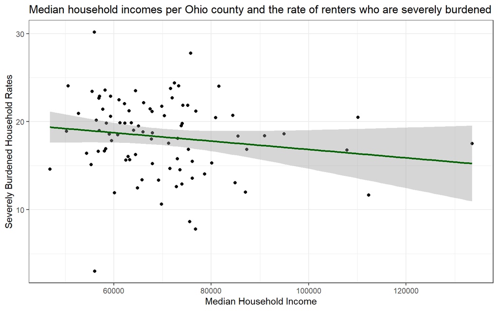

```r
library(ggplot2)

rent |>
  ggplot(aes(x = hh_income, y = severe_burden_rate)) +
  geom_point() + # Scatterplot of median household income against severe_burden_rate
  geom_smooth(method = "lm", color = "darkgreen") + #adding a regression line with standard error
  xlab("Median Household Income") +
  ylab("Severely Burdened Household Rates") +
  labs(title = "Median household incomes per Ohio county and the rate of renters who are severely burdened") +
  theme_bw()
```

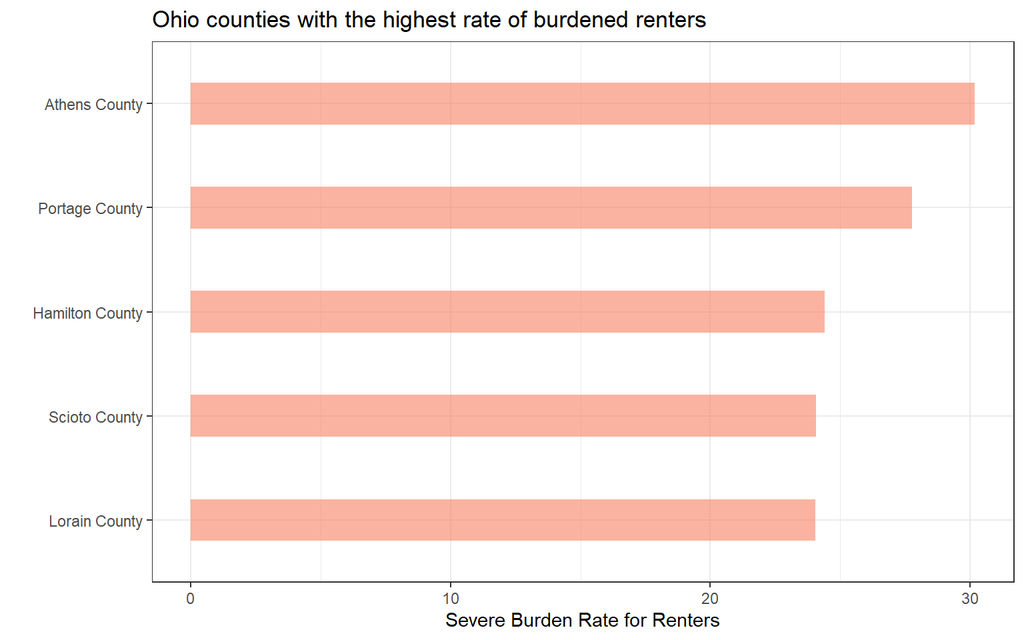

```r
#Bar chart of the top 5 and bottom 5 counties in Ohio. Using factor reordered data
rent_max |>
  ggplot(aes(county, severe_burden_rate)) +
   geom_bar(stat="identity", fill="#f68060", alpha=.6, width=.4) +
    coord_flip() +
    xlab("") +
    ylab("Severe Burden Rate for Renters") +
    labs(title = "Ohio counties with the highest rate of burdened renters") +
    theme_bw()
```

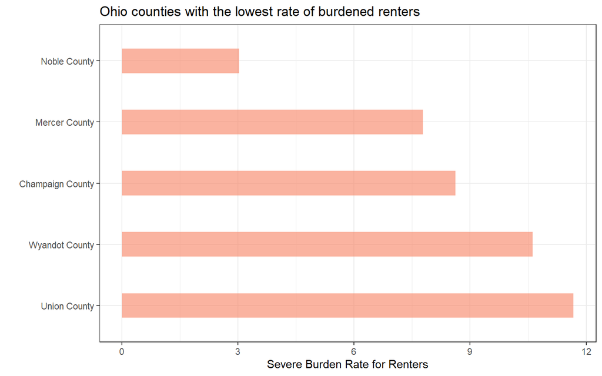

```r
rent_min |>
   ggplot(aes(county, severe_burden_rate)) +
   geom_bar(stat="identity", fill="#f68060", alpha=.6, width=.4) +
    coord_flip() +
    xlab("") +
    ylab("Severe Burden Rate for Renters") +
    labs(title = "Ohio counties with the lowest rate of burdened renters") +
    theme_bw()
```

# Part V. Civic Data Ethics

1. Privacy. [5 points] The 311 dataset includes the street address and coordinates of each request. Suppose you wanted to publish a map of West Town requests on your GitHub Page. Identify one privacy risk, then explain how you would apply one de-identification technique before publishing.

If I created a map where one could easily locate where each 311 was located, it would pose a risk to the people who lived near the street address and coordinates of the request. It would be easier for a skilled technologist with ill intentions to identify people or businesses the requests are associated to and use that information for personal gain. To de-identify the dataset, I would aggregate the complaints by community number rather than using a specific address or name. In this way, the information and the message remains the same, but it provides an additional layer of protection for the individuals in the data.

2. Bias and data quality. [5 points] 311 data shows where people report problems, which is not always where problems exist. Explain how this could mislead a city manager who assigns repair crews by request counts, and describe one way to check for or reduce that bias.

Sadly, civic data can reinforce existing prejudices within the people it is trying to help. If many requests are coming from a wealthier neighborhood like West Town, it could further exacerbate the inequalities in response time that other less wealthy neighborhoods experience on a daily basis. For example, if a wealthier neighborhood is getting a lot of complaints from many individuals for the same problem, it doesn’t necessarily mean it is a big problem; it is just getting more attention. There could exist an even bigger problem in a less wealthy neighborhood, but it can go unreported for reasons related to access, such as lack of internet, or a feeling of resignation because that’s just the way it’s always been. To ensure equal distribution, it’s necessary for city managers to check their preexisting bias before any decisions benefit some communities more than others. City managers would have to go where the data is missing to understand why it is so in the first place.

3. Scraping responsibly. [5 points] Using the criteria discussed in Week 5, explain whether the scraping you did in Part II was appropriate. Then describe one civic data situation where you should not scrape without further review.

The web scraping in Part II was appropriate because it involved public, non-personable, and factual data. It involved information that anybody could easily find on Wikipedia and from websites made specifically for practicing web scraping. It would be unethical to web scrape websites that require you to create a profile because those pages usually include interacting with others who share personally identifiable information. To participate with a website that requires you to create a profile, you are willingly acknowledging their terms of agreement, and so you would be obliged to follow their rules to keep users and copyright data safe.

AI USE STATEMENT: Used Gemini to correct syntax in Part III specifically for the parameters list. The quotation mark placements in httr are unusual. No AI was used elsewere.